# Evaluation of Invasive Plant Species Composition and Structural Diversity on the Big Island of Hawai’i

Mauna Loa, Ola’a, and Nahuku/East Rift

Environmental Data Analytics | Elizabeth Miles-Flynn & Irina Roybal

December 12, 2025

## 0.1 Git Repository

https://github.com/irinaroybal/MilesflynnRoybal_ENV872_EDA_FinalProject.git

## 0.2 List of Figures

**Figure** 3.1: Landsat mosaic of the Big Island of Hawaii, elevation in meters

**Figure** 3.2: Map showing the sampling sites are color-coded by region

**Figure** 4.1: Overall invasive species richness at each Site on the Big Island of Hawai’i

**Figure** 4.2: Invasive species richness by vegetation type at each site on the Big Island of Hawai’i

**Figure** 4.3: 2010 to 2023 Detection of invasive species for each site on the Big Island of Hawai’i

**Figure** 4.4: Locations of highly invasive species on the Big Island

**Figure** 4.5: Invasive fern species abundance at each site on the Big Island of Hawai’i

**Figure** 4.6: Invasive grass species abundance at each site on the Big Island of Hawai’i

**Figure** 4.7: Invasive herb species abundance at each site on the Big Island of Hawai’i

**Figure** 4.8: Invasive rush species abundance at each site on the Big Island of Hawai’i

**Figure** 4.9: Invasive sedge species abundance at each site on the Big Island of Hawai’i

**Figure** 4.10: Invasive shrub species abundance at each site on the Big Island of Hawai’i

**Figure** 4.11: Invasive tree species abundance at each site on the Big Island of Hawai’i

**Figure** 4.12: Invasive tree fern species abundance at each site on the Big Island of Hawai’i

**Figure** 4.13: Invasive vine species abundance at each site on the Big Island of Hawai’i

*For section “4.3 Diversity of Invasive Species Across Habitat Type”, tab numbers do not reflect the numbers of the figures, which are present in the figure caption underneath each graph.

# 1 Rationale and Research Questions

The purpose of this study is to analyze the spatial distribution of invasive species across three study sites on the Big Island of Hawai‘i. Prior to Polynesian arrival in the remote Pacific, new invasive species established naturally at an estimated rate of one species every 50,000 years. After Polynesian settlement, this rate increased to roughly three to four species every hundred years (Young 2016). Following European contact, the introduction rate accelerated dramatically to approximately twenty invasive species per year in Hawai‘i (Ewell 1999). While non-native species include any organisms introduced outside their natural range, only a subset of them become invasive. Invasive species are defined as non-native organisms that spread rapidly and/or cause ecological, economic, or cultural harm. These invasive species pose a substantial threat to Hawai‘i’s unique native biota. Of the roughly 10,000 native species found across the Hawaiian Islands, nearly 90% are endemic—occurring nowhere else on Earth (Cordell 2021). Our goal is to evaluate the invasive species on the Big Island across three study sites over the past thirteen years to inform best management practices to protect endemic species of the Hawaiian Islands. Our dataset focuses on three sites on the Big Island: Mauna Loa, Ola’a, and Nahuku/East Rift. Mauna Loa is classified as a subalpine shrubland, and Ola’a and Nahuku/East Rift are considered wet forest habitats. Our dataset ranges from 2010 to 2023 and contains coordinates for each survey site where a transect was used to count species-level observations and counts of repeated occurrences.

**Through our analysis, we aim to answer the following research questions:**

1. **Does invasive species’ richness change across the three sample regions?**
2. **Does invasive species’ structural diversity change across the three sample regions?**
3. **How does the frequency and distribution of invasive species change over time for each site?**

We hypothesize that there will be a significant difference in species richness and structural diversity between habitats and vegetation types. Previous research in Hawai’i Volcanoes National Park shows that there is a sharp transition between wet forests and subalpine shrubland at 2000 millimeter mean annual precipitation. A Hawaiian treeline ecotones study attributed the phenomenon to distinct changes in soil moisture (Ainsworth and Drake 2024). We predict that both wet forest types will have a more rapid increase in invasive species introduction over time than Mauna Loa. This expectation is based on reduced physical barriers (e.g., less steep terrain, increased connectivity with other habitat types), higher resource availability, more human/animal activity to disperse propagules, and a wider range of ecological niches for invasive species to occupy.

# 2 Dataset Information

Raw data was derived from the United States Government’s open data site starting from October 4th, 2010 to September 7th, 2023. This dataset is part of The Pacific Island Inventory and Monitoring Network (PACN) Established Invasive Plant Species (EIPS) Monitoring Protocol. More information on the sources used can be found in the table below:

| Detail | Description |
| --- | --- |
| Name | Pacific Island Network Established Invasive Plant Species Monitoring Dataset 2010-2022 |
| Publisher | National Park Service |
| Retrieved From | https://catalog.data.gov/dataset/pacific-island-network-established-invasive-plant-species-monitoring-dataset-2010-2022 |
| Variables Used | Plant Community, Sampling Frame, Decimal Latitude, Decimal Longitude, Date, Species Code, Scientific Name, Vernacular Name, Vegetation Type |
| Date Range | October 4, 2010 to September 7, 2023 |

# 3 Exploratory Analysis

## 3.1 Exploration of Raw Data

The raw dataset included 37977 observations across 33 variables, including sampling date, plant community (e.g., wet forest, subalpine shrubland), transect number and type, transect latitude and longitude, datum, species, and life form (which we later refer to as “vegetation type”), among others. There were also several NA values which were subsequently omitted from our processed dataset.

```
## 'data.frame':    37977 obs. of  33 variables:
##  $ samplingProtocol       : chr  "Established Invasive Plant Species" "Established Invasive Plant Species" "Established Invasive Plant Species" "Established Invasive Plant Species" ...
##  $ year                   : int  2010 2010 2010 2010 2010 2010 2010 2010 2010 2010 ...
##  $ custom_cycle           : int  1 1 1 1 1 1 1 1 1 1 ...
##  $ custom_unitCode        : chr  "HAVO" "HAVO" "HAVO" "HAVO" ...
##  $ custom_plantCommunity  : chr  "Wet Forest" "Wet Forest" "Wet Forest" "Wet Forest" ...
##  $ custom_samplingFrame   : chr  "Nahuku / East Rift" "Nahuku / East Rift" "Nahuku / East Rift" "Nahuku / East Rift" ...
##  $ custom_transectType    : chr  "Fixed" "Fixed" "Fixed" "Fixed" ...
##  $ custom_transectNumber  : chr  "1" "1" "1" "1" ...
##  $ decimalLatitude        : num  19.4 19.4 19.4 19.4 19.4 ...
##  $ decimalLongitude       : num  -155 -155 -155 -155 -155 ...
##  $ geodeticDatum          : chr  "EPSG: 4326" "EPSG: 4326" "EPSG: 4326" "EPSG: 4326" ...
##  $ custom_startDate       : chr  "2010-11-15" "2010-11-15" "2010-11-15" "2010-11-15" ...
##  $ custom_endDate         : chr  "2010-11-15" "2010-11-15" "2010-11-15" "2010-11-15" ...
##  $ custom_eventTimeStart  : chr  NA NA NA NA ...
```

[output cut: 19 more lines]

## 3.2 Study Site

Three regions within Hawai‘i Volcanoes National Park were selected as the Big Island contained the most sampling sites out of all the Hawaiian Islands in the dataset. All invasive plant species were counted within 5 × 20 m plots at each site, allowing for comparison between wet forest and subalpine shrubland habitats. Figure 3.1 displays a Landsat mosaic of the approximate location and average elevation of our three study regions. In Figure 3.2, sampling sites are color-coded by region. Studies characterize wet forests with greater wet canopy evaporation, annual mean precipitation and temperature. Subalpine shrublands are found at higher elevations with cooler temperatures and experience greater soil evaporation (Ainsworth and Drake 2024). Mauna Loa, the subalpine shrubland, is depicted in orange. Wet forest habitat types are shown in blue, with Nāhuku/East Rift in light blue and Ola‘a in dark blue.

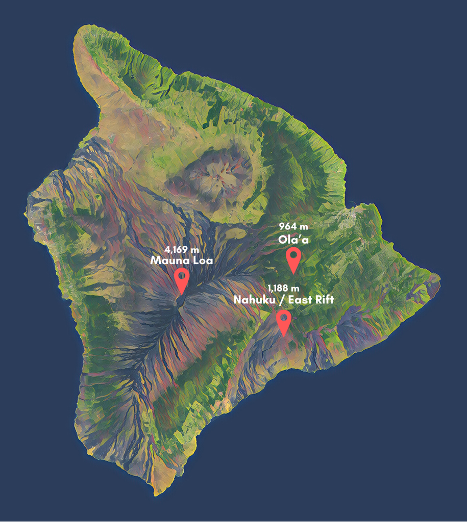

Figure 3.1: Landsat Mosaic of Big Island of Hawaii, Average Elevation (m)

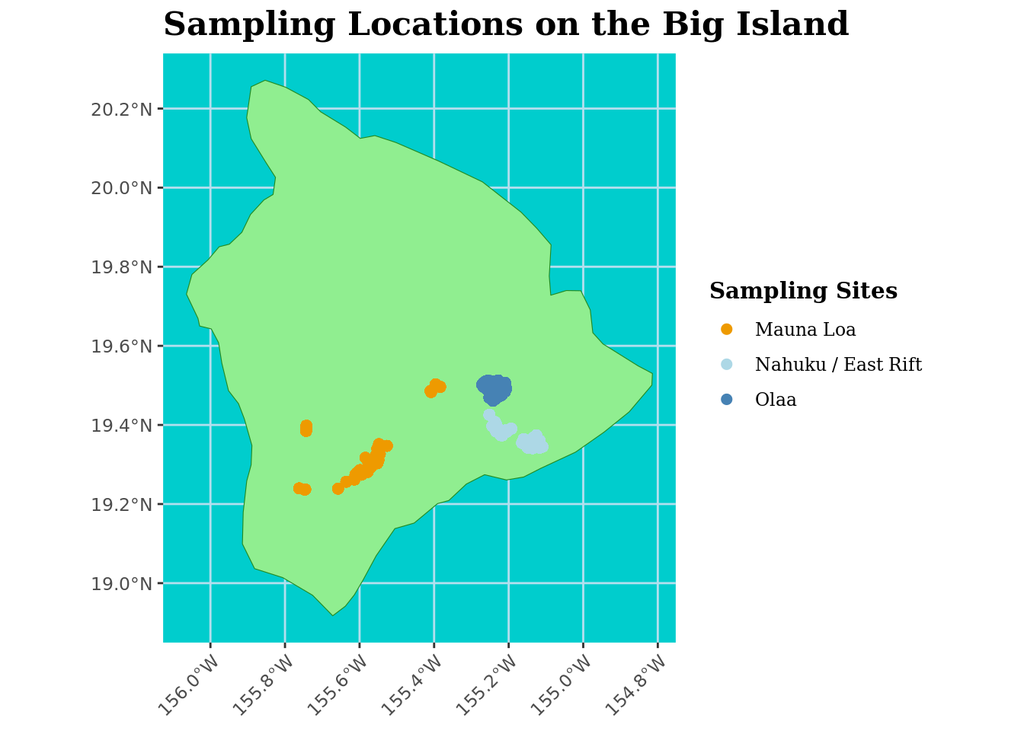

Figure 3.2: Map showing the sampling sites are color-coded by region

## 3.3 Data Wrangling

After preliminary raw data exploration, we filtered for the three sampling sites (Mauna Loa, Nahuku/East Rift, and Ola’a) on the Big Island of Hawai’i. We selected the following variables that better suit our analyses and renamed each column by removing “custom_” prefix: Plant Community, Sampling Frame, Decimal Latitude, Decimal Longitude, Date, Species Code, Scientific Name, Vernacular Name, and Vegetation Type. The wrangled, processed dataset was saved as “BigIsland_Processed.csv”. Another dataset, “BigIsland_Clean.csv”, was used to conduct ANOVA and Tukey Post-Hoc tests as these statistical analyses required transect numbers.

# 4 Analysis

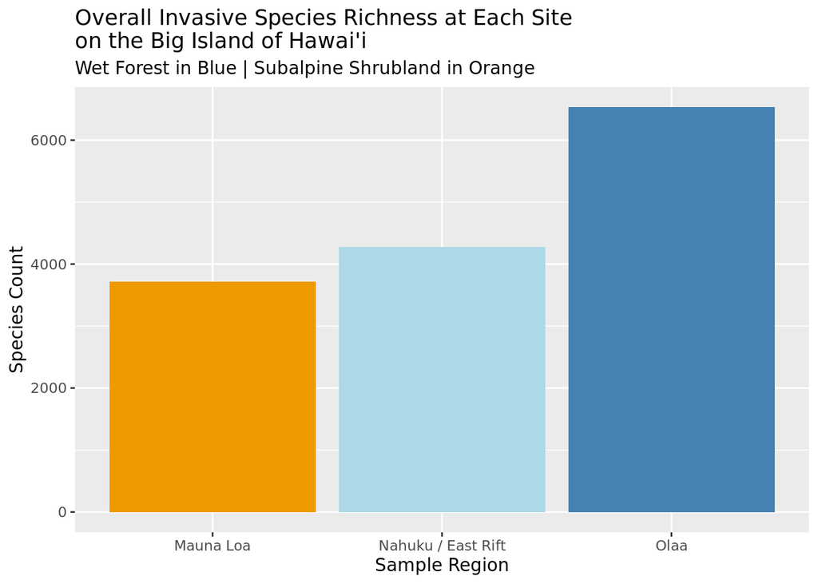

Figure 4.1: Overall Invasive Species Richness at Each Site on the Big Island of Hawai’i

**Site Region Richness:** Our results support our hypothesis that Mauna Loa had the lowest overall invasive species richness compared to other regions. Higher elevation environments such as Mauna Loa tend to experience less invasive species; likely due to harsher environmental conditions, short growing seasons, and steep terrain that limit their persistence. Notably, Ola’a has the lowest average elevation and the greatest invasive species richness. Lower elevations tend to have milder climates that support favorable conditions for diverse species growth and proliferation (Ainsworth and Drake 2024).

Our ANOVA test revealed that there was a significant difference in overall invasive species richness between Ola’a and Mauna Loa (p-value of 0.028). There was no meaningful significance in invasive species richness between Nahuku / East Rift and Mauna Loa (p-value of 0.161) and Ola’a and Nahuku / East Rift (p-value of 0.803). We chose to define richness as the number of distinct species types at a given transect by using the function “n_distinct”, negating repeated counts of species occurrence. In doing so, we were able to assign richness scores to each transect and averaged across study regions to determine their respective invasive species richness. After running a Tukey Post-Hoc Test, we found that Ola’a has an overall higher invasive species richness relative to Mauna Loa.

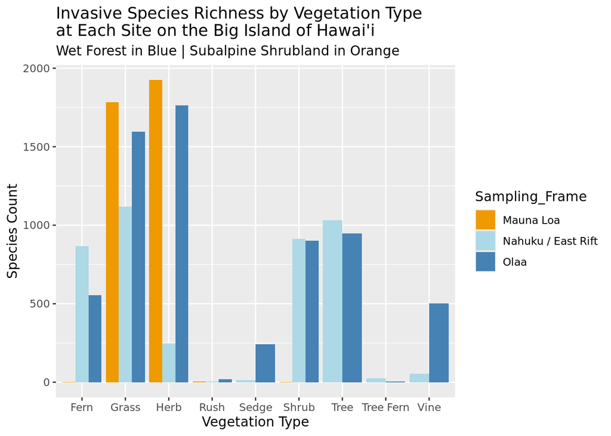

Figure 4.2: Invasive Species Richness by Vegetation Type at Each Site on the Big Island of Hawai’i

An ANOVA test analyzing the significance of structural differences between study regions found that Nahuku / East Rift, Ola’a, and Mauna Loa all had significant differences in structural diversity. By aggregating the number of vegetation types found at each transect/sampling point, we are able to determine the structural diversity of a given point and translate regional patterns into comparable data that is then analyzed for statistical significance (i.e. a site with tree + shrub + fern + grass receives a diversity score of 4, whereas a site with only grass + shrub receives diversity score of 2). A Tukey Post-Hoc test revealed that Ola’a has a greater structural diversity than Mauna Loa with a mean difference of 4.527. Nahuku-East Rift is also more structurally diverse than Mauna Loa with a mean difference of 3.081. Ola’a also has a higher structural diversity than Nahuku / East Rift with a mean difference of 1.446, though this difference is comparably less pronounced. This suggests that overall, Ola’a has the greatest structural diversity, followed by Nahuku / East Rift, and Mauna Loa with the lowest structural diversity.

## 4.1 Time Series of Invasive Plants

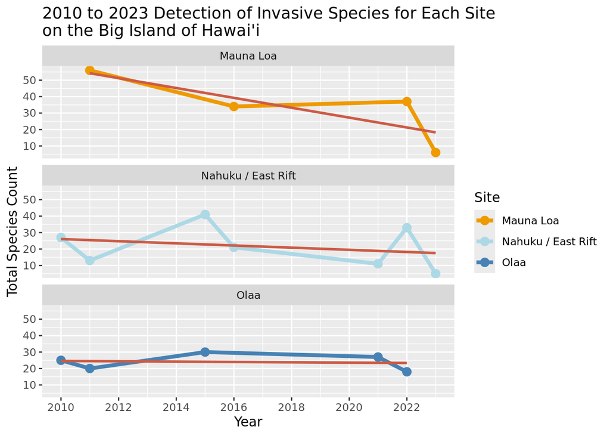

Figure 4.3: 2010 to 2023 Detection of Invasive Species for Each Site on the Big Island of Hawai’i

## 4.2 Specific Invasive Species Map Exploration

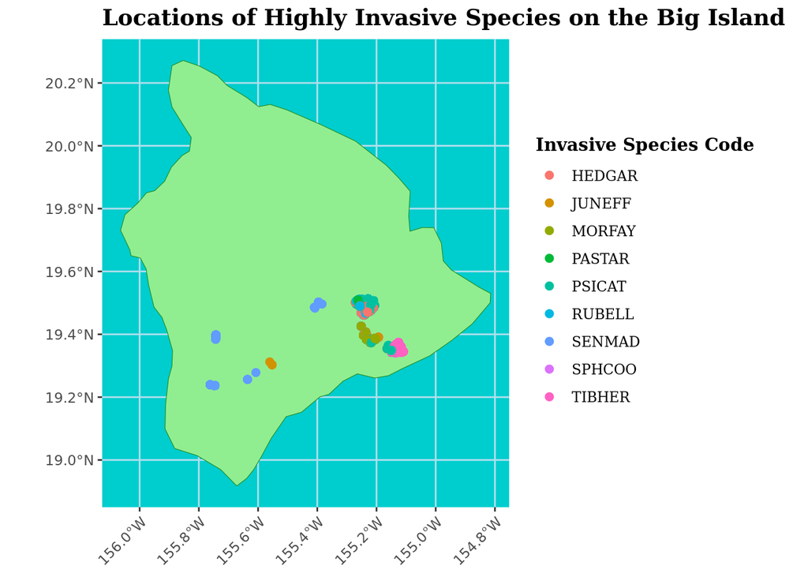

Figure 4.4: Locations of Highly Invasive Species on the Big Island

## 4.3 Diversity of Invasive Species Across Habitat Type

### 4.3.1 FERN

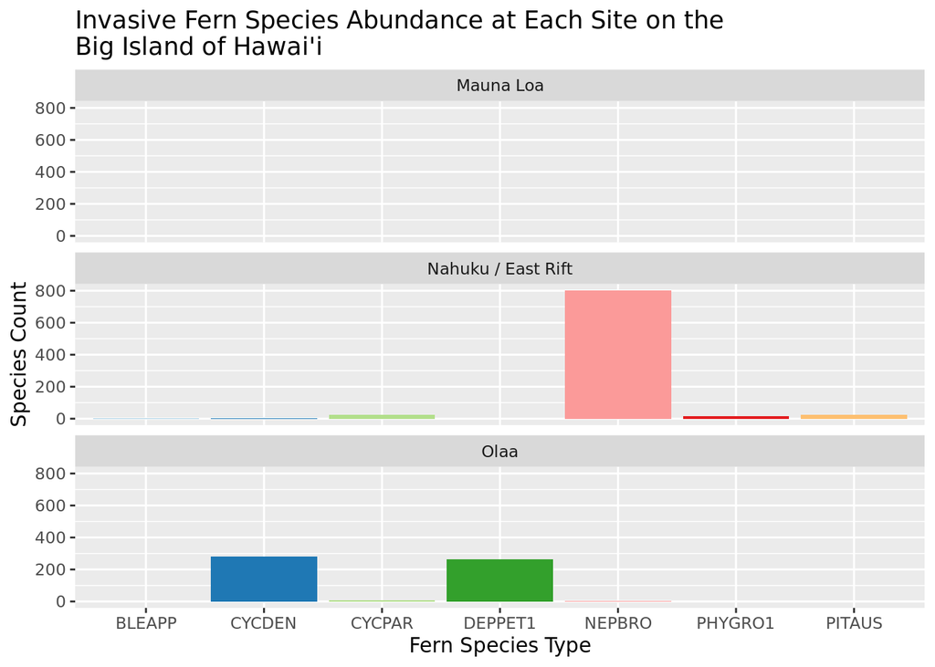

Figure 4.5: Invasive Fern Species Abundance at Each Site on the Big Island of Hawai’i

### 4.3.2 GRASS

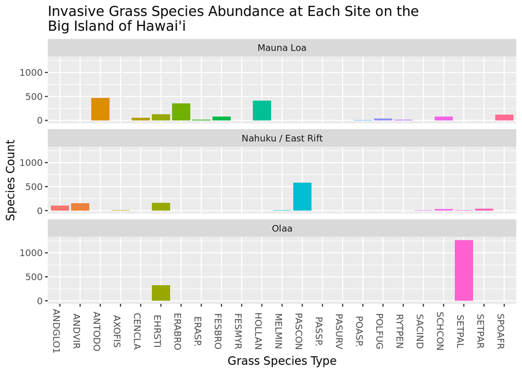

Figure 4.6: Invasive Grass Species Abundance at Each Site on the Big Island of Hawai’i

### 4.3.3 HERB

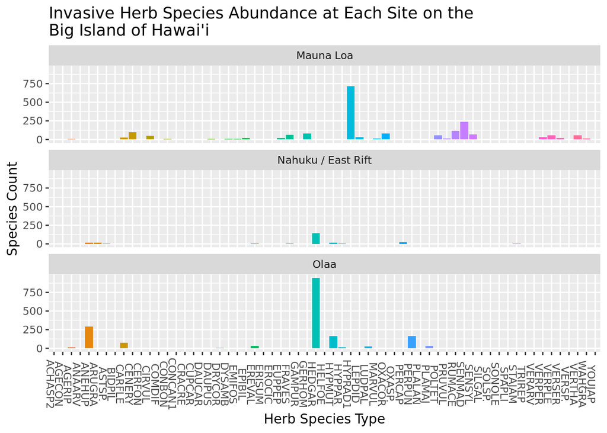

Figure 4.7: Invasive Herb Species Abundance at Each Site on the Big Island of Hawai’i

### 4.3.4 RUSH

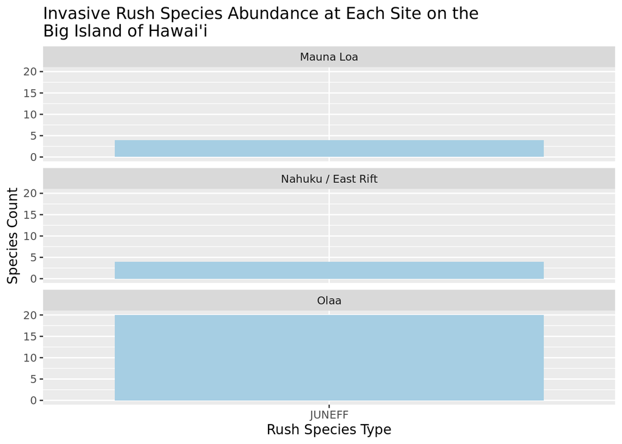

Figure 4.8: Invasive Rush Species Abundance at Each Site on the Big Island of Hawai’i

### 4.3.5 SEDGE

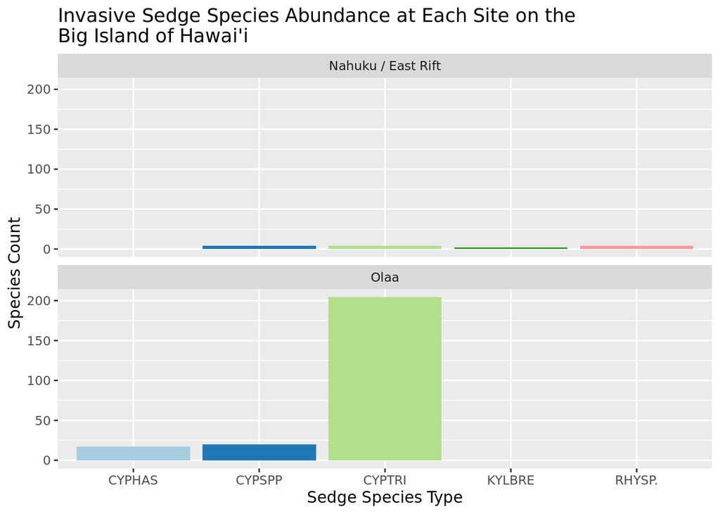

Figure 4.9: Invasive Sedge Species Abundance at Each Site on the Big Island of Hawai’i

### 4.3.6 SHRUB

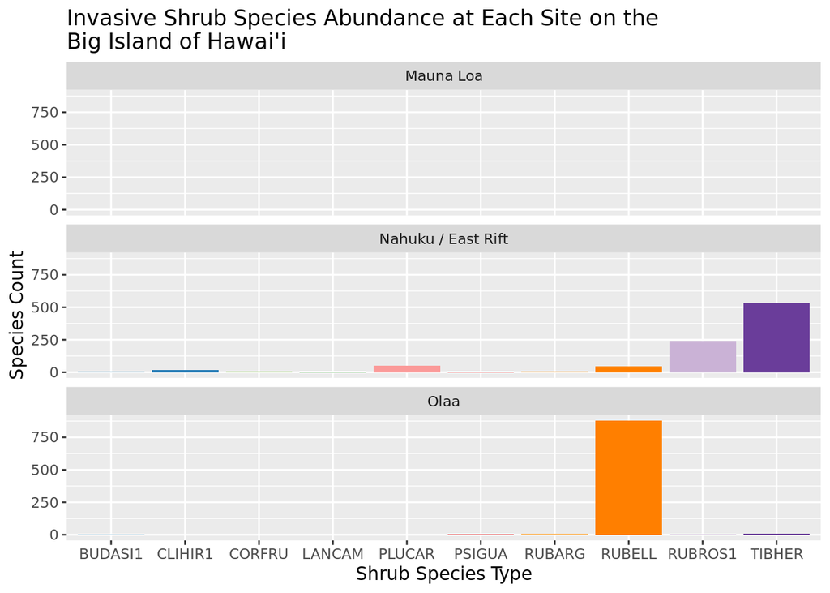

Figure 4.10: Invasive Shrub Species Abundance at Each Site on the Big Island of Hawai’i

### 4.3.7 TREE

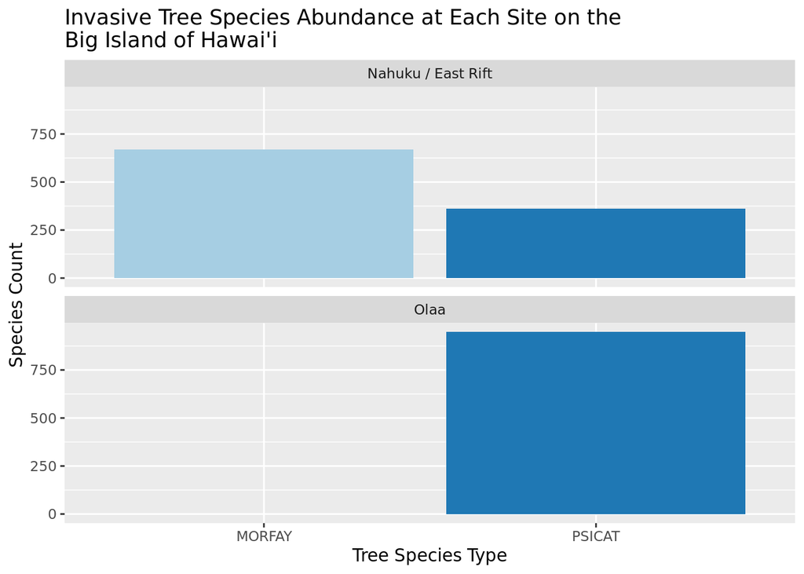

Figure 4.11: Invasive Tree Species Abundance at Each Site on the Big Island of Hawai’i

### 4.3.8 TREE FERN

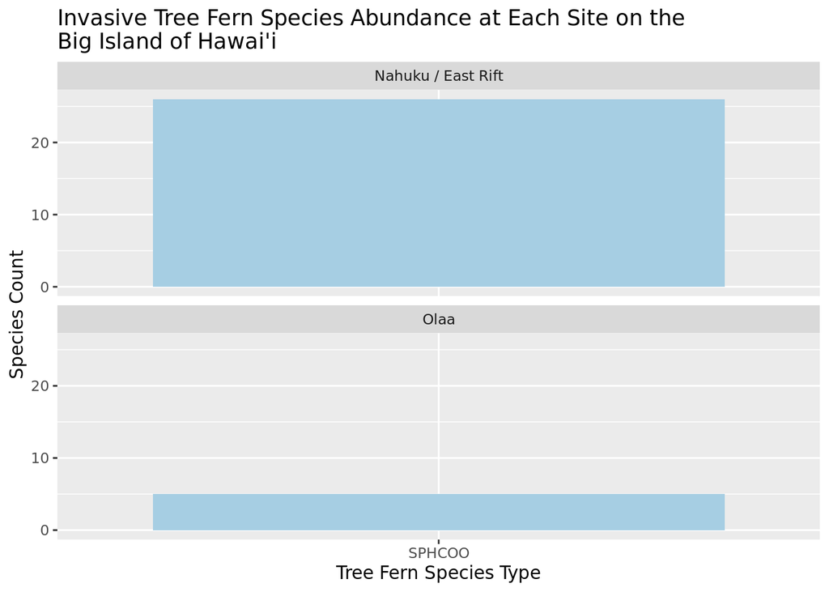

Figure 4.12: Invasive Tree Fern Species Abundance at Each Site on the Big Island of Hawai’i

### 4.3.9 VINE

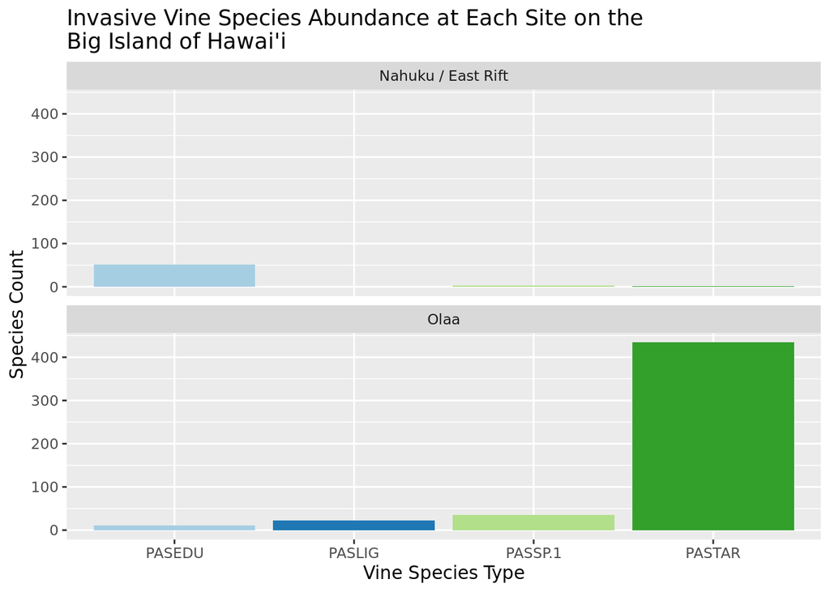

Figure 4.13: Invasive Vine Species Abundance at Each Site on the Big Island of Hawai’i

Figure 4.3 displays a total invasive species count over time across study regions. This count includes multiple observations of the same species at a given sample site. It appears that while levels have fluctuated in the past 12-13 years, there has been an overall decrease in invasive species counts across all three regions. Mauna Loa is experiencing the greatest decrease with about 3 less invasive species counted annually. Nahuku / East Rift is declining by approximately 0.6558 species per year. Ola’a has experienced little to no fluctuation in the number of invasive species with an average decline of 0.1059 species annually. One important feature to note are the points on the graph representing the times that each region was sampled. Given that these sampling windows are limited and occurred sporadically throughout the time span, trends observed are likely not very substantial but do warrant further investigation.

# 5 Summary and Conclusions

Our results show that invasive species richness does change across the sample regions. Figure 4.1 displays the overall invasive species richness across the 13-year sampling protocol. Ola’a appears to have the greatest species richness across the study regions, followed by Nahuku / East Rift. Mauna Loa has the least species richness out of the three regions. This finding was somewhat supported by our ANOVA (analysis of variance) and Tukey Post-Hoc test, which found that Ola’a has significantly higher invasive species richness in comparison to Mauna Loa. There is no statistically significant difference between Ola’a & Nahuku / East Rift and Mauna Loa and Nahuku / East Rift.

These phenomena are likely attributed to:

- Higher resource availability in wet forest habitat types
- Less human/animal activity to disperse propagules in subalpine shrubland habitats
- Wider range of ecological niches for invasive species to occupy in wet forest habitat types
- Altitude, soil moisture, and wind pattern differences among habitat types
- Reduced physical barriers in wet forest habitat types
  - Less steep terrain
  - Increased connectivity with other habitat types

However, further analysis and data regarding elevation, rainfall, wind, and other potential drivers are required to confirm these theories as they pertain to our specific dataset. While we had two wet forest habitats to compare, our analysis would be made stronger if we had additional subalpine shrubland regions to confirm if the patterns we observed on Mauna Loa can be extrapolated to this habitat type as a whole on the Big Island of Hawai’i.

Trends varied across time. Throughout the three study regions, the number of invasive plants counted decreased on average. Though our time series results are likely anecdotal, some claims are somewhat substantiated by research conducted on the Big Island. One paper found that “while most of the area occupied by invasive species increased in size, the area of two highly invasive species occupying upper elevation wet forest decreased dramatically” (Cordell 2021). A useful next step in exploring these trends would be to have a longer timeline of invasive species spread. While our findings suggest that invasive species populations are largely stable across the study regions, this may be an outlier in the long-term trends of the island. Further, as we only have three study regions to pull data from, we are only able to speak to the local trends at these sites. Perhaps the increased protectivity within the Hawai’i Volcanoes National Park has allowed these regions to maintain or even decrease invasive species counts, whereas the rest of the Big Island has an entirely different experience.

Understanding regional trends in invasive species populations is key to informing best practices for land management, tailoring restoration techniques on a case-by-case basis. Invasive species aren’t the only threat to the endemic plants of Hawai’i, instead “extinction is projected for some native plant populations when habitat area is defined by climatic envelopes is impinged by sea level rise on the lower end and elevation at the upper end” (Fortini et al., 2013). This may put high-elevation sites such as Mauna Loa at greater risk of losing native plants, which is only exacerbated by added competition from invasive species.

# 6 References

Ainsworth, A., & Drake, D. R. (2024). Hawaiian treeline ecotones: Implications for plant community conservation under climate change. Plants, 13(1), 123.

Cordell, S. (2020). Hawaii and US-affiliated Pacific Islands: Regional summaries. In S. J. Seybold, S. J. Frankel, D. H. Olson, R. Flitcroft, B. K. Kerns, J. Lee, K. L. Ripley, & A. S. Munson (Eds.), Invasive species in forests and grasslands of the United States: A comprehensive ecological assessment. U.S. Department of Agriculture, Forest Service. https://www.fs.usda.gov/research/publications/book/invasiveSpecies/invasiveSpeciesAppendixHawaiiPacificIslands.pdf

Ewel, J. J., O’Dowd, D. J., Bergelson, J., Daehler, C. C., D’Antonio, C. M., Gómez, L. D., Gordon, D. R., Hobbs, R. J., Holt, A., & Hopper, K. R. (1999). Deliberate introductions of species: Research needs, benefits can be reaped, but risks are high. BioScience, 49(8), 619–630.

Fortini, L., Price, J., Jacobi, J., Vorsino, A., Burgett, J., Brinck, K., Amidon, F., Miller, S., Gon III, S. ʻO., Koob, G., & Paxton, E. (2013, November). A landscape-based assessment of climate change vulnerability for all native Hawaiian plants (Technical Report HCSU-044). Hawai‘i Cooperative Studies Unit, University of Hawai‘i at Hilo. https://hilo.hawaii.edu/hcsu/documents/TR44_Fortini_plant_vulnerability_assessment.pdf

Hawaiʻi Department of Agriculture & Biosecurity. (2011). Final EA posted for biological control of invasive strawberry guava [Press release]. Hawaiʻi Department of Agriculture. https://dab.hawaii.gov/blog/news-releases/final-ea-posted-for-biological-control-of-invasive-strawberry-guava/

Hawaiʻi Invasive Species Council. (2023). Invasive species profiles [Website]. Hawaiʻi Department of Land and Natural Resources. https://dlnr.hawaii.gov/hisc/info/invasive-species-profiles/

National Park Service. (2021, February 18). Ferns – Hawaiʻi Volcanoes National Park [Web page]. U.S. Department of the Interior. https://www.nps.gov/havo/learn/nature/ferns.htm

National Park Service, Pacific Island Inventory & Monitoring Network. (2025, November 25). Pacific Island Network established invasive plant species monitoring dataset, 2010–2022 [Data set]. Data.gov. https://catalog.data.gov/dataset/pacific-island-network-established-invasive-plant-species-monitoring-dataset-2010-2022

Young, H. S., McCauley, D. J., & Dunne, J. A. (2016). The role of species interactions in food web stability: A multi-level approach. Canadian Journal of Zoology, 94(12), 939–949.